# Perfiles Epidemiológicos - Pueblos Originarios (OPTIMIZADO)

## 4. Top 20 Diagnósticos - Pueblos Originarios

### 4.1. Tabla con tasas y proporciones (FUNCIÓN MODULAR)

```r
cat("\n═══ TOP 20 DIAGNÓSTICOS - PUEBLOS ORIGINARIOS ═══\n")
```

```
═══ TOP 20 DIAGNÓSTICOS - PUEBLOS ORIGINARIOS ═══
```

```r
# Usar función modular calcular_perfil_diagnostico()
# Esta función automáticamente:
# - Filtra por pertenencia
# - Calcula tasas anuales por 1000 persona-años
# - Calcula proporciones por 1000 egresos
# - Calcula % sobre total y % acumulado
# - Ordena por frecuencia descendente

perfil_po <- calcular_perfil_diagnostico(
  datos = datos_diag_preparados,
  pertenencia = 1,
  poblacion = pob_po,
  total_egresos = total_egresos_po,
  anos_estudio = anos_estudio,
  top_n = 20,
  min_casos = 1,
  verbose = TRUE
)
```

```
═══ CALCULANDO PERFIL: Pueblos Originarios ═══
  ✓ Top 20 diagnósticos calculados
  ✓ Tasa anual promedio: 28.37 x1000 persona-años
```

```r
cat("\n")
```

```r
# Usar función modular crear_tabla_perfil()
# Esta función automáticamente:
# - Formatea tabla con flextable
# - Aplica estilos según tipo (perfil/comparacion)
# - Resalta filas según umbral
# - Genera título y pie de tabla

tabla_perfil_po <- crear_tabla_perfil(
  datos = perfil_po,
  tipo = "perfil",
  titulo = "Top 20 Diagnósticos - Pueblos Originarios (Tasas y Proporciones)",
  resaltar_umbral = 5,
  col_umbral = "pct_total",
  color_resaltado = "#E8F4F8",
  tamano_fuente = 8
)

print(tabla_perfil_po)
```

```
a flextable object.
col_keys: `ranking`, `DIAG_COMPLETO`, `n_casos`, `tasa_anual`, `prop_x1000_egresos`, `pct_total`, `pct_acumulado`
header has 1 row(s)
body has 20 row(s)
original dataset sample:
  ranking                                                   DIAG_COMPLETO
1       1 O800 - PARTO UNICO ESPONTANEO, PRESENTACION CEFALICA DE VERTICE
2       2          O809 - PARTO UNICO ESPONTANEO, SIN OTRA ESPECIFICACION
3       3               O829 - PARTO POR CESAREA, SIN OTRA ESPECIFICACION
4       4          K358 - OTRAS APENDICITIS AGUDAS Y LAS NO ESPECIFICADAS
5       5           K802 - CALCULO DE LA VESICULA BILIAR SIN COLECISTITIS
  n_casos tasa_anual prop_x1000_egresos pct_total pct_acumulado
1  118009   4.153010           37.85282  3.785282      3.785282
2  112272   3.951111           36.01261  3.601261      7.386542
3   75714   2.664551           24.28618  2.428618      9.815161
4   68548   2.412363           21.98760  2.198760     12.013921
5   64187   2.258889           20.58876  2.058876     14.072797
```

```r
# Guardar con función modular
guardar_tabla_html(tabla_perfil_po, "perfiles/perfil_po_top20_tasas.html")
```

```
Tabla guardada como: resultados_tesis/perfiles/perfil_po_top20_tasas.html
```

```
[1] TRUE
```

```r
cat("\n✓ Top 20 representan:",
    sprintf("%.1f%%", sum(perfil_po$pct_total)),
    "del total de egresos PO\n")
```

```
✓ Top 20 representan: 25.9% del total de egresos PO
```

### 4.2. Gráfico - Top 20 PO (FUNCIÓN MODULAR)

```r
cat("═══ GRÁFICO TOP 20 - PUEBLOS ORIGINARIOS ═══\n")
```

```
═══ GRÁFICO TOP 20 - PUEBLOS ORIGINARIOS ═══
```

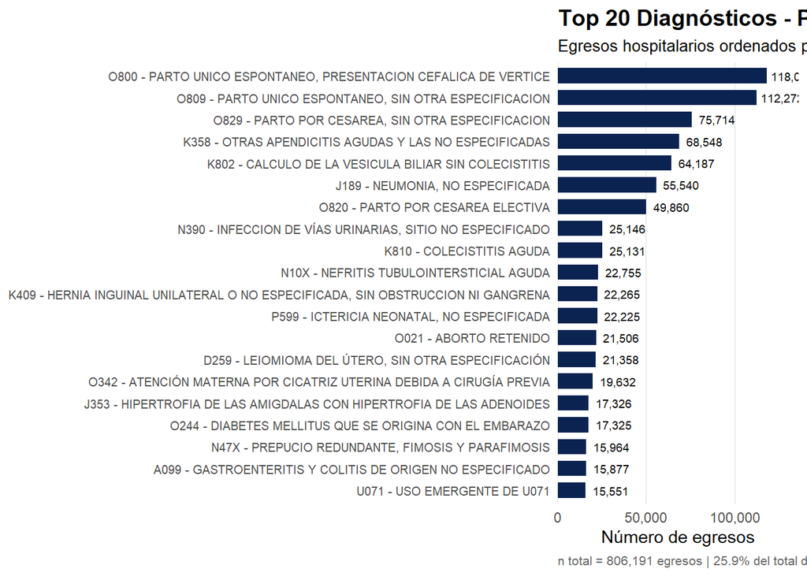

```r
# Usar función modular graficar_perfil_top()
# Esta función automáticamente:
# - Genera gráfico de barras horizontales
# - Ordena por frecuencia
# - Aplica colores personalizados
# - Agrega etiquetas de valores
# - Formatea ejes y títulos

graf_perfil_po <- graficar_perfil_top(
  datos = perfil_po,
  titulo = "Top 20 Diagnósticos - Pueblos Originarios",
  subtitulo = "Egresos hospitalarios ordenados por frecuencia (2010-2022)",
  color_barras = "#0A2351",
  mostrar_etiquetas = TRUE,
  tamano_etiquetas = 2.5
)

print(graf_perfil_po)
```

```r
# Guardar con función modular
guardar_multiformato(graf_perfil_po, "perfiles/perfil_po_top20", 12, 9, 300)

cat("✓ Gráfico guardado en: resultados_tesis/perfiles/\n")
```

```
✓ Gráfico guardado en: resultados_tesis/perfiles/
```

## 5. Comparación PO vs PG

### 5.1. Diagnósticos con mayor diferencia de tasas (FUNCIÓN MODULAR)

```r
cat("\n═══ COMPARACIÓN DE TASAS PO vs PG ═══\n")
```

```
═══ COMPARACIÓN DE TASAS PO vs PG ═══
```

```r
# Usar función modular comparar_perfiles_po_pg()
# Esta función automáticamente:
# - Calcula perfiles para PO y PG
# - Cruza ambos perfiles por diagnóstico
# - Calcula diferencias absolutas y relativas
# - Calcula RR crudo (sin ajuste por edad)
# - Identifica sobre/subrepresentación
# - Ordena por diferencia de tasas

comparacion_diag <- comparar_perfiles_po_pg(
  datos = datos_diag_preparados,
  poblacion_po = pob_po,
  poblacion_pg = pob_pg,
  total_egresos_po = total_egresos_po,
  total_egresos_pg = total_egresos_pg,
  anos_estudio = anos_estudio,
  min_casos_po = 100,
  top_n = 20,
  ordenar_por = "dif_tasa",
  verbose = TRUE
)
```

```
═══ COMPARANDO PERFILES PO vs PG ═══
  ✓ 20 diagnósticos comparados (≥100 casos en PO)
  ✓ Sobre-representados en PO (RR≥1.5): 11
  ✓ Sub-representados en PO (RR≤0.67): 0

  ⚠ ADVERTENCIA: RR crudos sin ajuste por edad
```

```r
cat("\n✓ Top", nrow(comparacion_diag), "diagnósticos identificados\n")
```

```
✓ Top 20 diagnósticos identificados
```

```r
# Mostrar clasificación
n_sobre <- sum(comparacion_diag$clasificacion == "Sobrerrepresentado", na.rm = TRUE)
n_sub <- sum(comparacion_diag$clasificacion == "Subrepresentado", na.rm = TRUE)
n_similar <- sum(comparacion_diag$clasificacion == "Similar", na.rm = TRUE)
cat("\nCLASIFICACIÓN:\n")
```

```
CLASIFICACIÓN:
```

```r
cat("  • Sobrerrepresentados (RR ≥ 1.5):", n_sobre, "diagnósticos\n")
```

```
  • Sobrerrepresentados (RR ≥ 1.5): 0 diagnósticos
```

```r
cat("  • Subrepresentados (RR ≤ 0.67):", n_sub, "diagnósticos\n")
```

```
  • Subrepresentados (RR ≤ 0.67): 0 diagnósticos
```

```r
cat("  • Similares:", n_similar, "diagnósticos\n\n")
```

```
  • Similares: 0 diagnósticos
```

### 5.2. Tabla de comparación (FUNCIÓN MODULAR)

```r
cat("═══ TABLA DE COMPARACIÓN ═══\n")
```

```
═══ TABLA DE COMPARACIÓN ═══
```

```r
# Usar función modular crear_tabla_perfil() con tipo = "comparacion"
# Esta función automáticamente:
# - Formatea columnas para comparación
# - Destaca diferencias significativas
# - Aplica colores según RR
# - Muestra clasificación

tabla_comparacion <- crear_tabla_perfil(
  datos = comparacion_diag,
  tipo = "comparacion",
  titulo = "Comparación de Tasas PO vs PG - Top 20 Diferencias",
  tamano_fuente = 8
)

print(tabla_comparacion)
```

```
a flextable object.
col_keys: `DIAG1`, `casos_po`, `casos_pg`, `tasa_anual_po`, `tasa_anual_pg`, `dif_tasa_anual`, `prop_po`, `prop_pg`, `dif_prop`, `rr_crudo`, `rr_prop`, `direccion`, `DIAG_COMPLETO`
header has 1 row(s)
body has 20 row(s)
original dataset sample:
  DIAG1 casos_po casos_pg tasa_anual_po tasa_anual_pg dif_tasa_anual  prop_po
1  O800   118009   432196      4.153010      2.232721      1.9202889 37.85282
2  O809   112272   414657      3.951111      2.142114      1.8089970 36.01261
3  K358    68548   300460      2.412363      1.552174      0.8601890 21.98760
4  O829    75714   375752      2.664551      1.941132      0.7234193 24.28618
5  K802    64187   297253      2.258889      1.535606      0.7232826 20.58876
   prop_pg  dif_prop rr_crudo  rr_prop direccion
1 24.22703 13.625789 1.860067 1.562421     ↑↑ PO
2 23.24387 12.768737 1.844491 1.549338     ↑↑ PO
3 16.84248  5.145121 1.554183 1.305485     ↑↑ PO
4 21.06302  3.223160 1.372679 1.153025      ↑ PO
5 16.66271  3.926048 1.471008 1.235619      ↑ PO
                                                    DIAG_COMPLETO
1 O800 - PARTO UNICO ESPONTANEO, PRESENTACION CEFALICA DE VERTICE
2          O809 - PARTO UNICO ESPONTANEO, SIN OTRA ESPECIFICACION
3          K358 - OTRAS APENDICITIS AGUDAS Y LAS NO ESPECIFICADAS
4               O829 - PARTO POR CESAREA, SIN OTRA ESPECIFICACION
5           K802 - CALCULO DE LA VESICULA BILIAR SIN COLECISTITIS
```

```r
# Guardar
guardar_tabla_html(tabla_comparacion, "perfiles/comparacion_tasas_po_pg.html")
```

```
Tabla guardada como: resultados_tesis/perfiles/comparacion_tasas_po_pg.html
```

```
[1] TRUE
```

```r
cat("✓ Tabla guardada en: resultados_tesis/perfiles/comparacion_tasas_po_pg.html\n")
```

```
✓ Tabla guardada en: resultados_tesis/perfiles/comparacion_tasas_po_pg.html
```

### 5.3. Gráfico de diferencias de tasas (FUNCIÓN MODULAR)

```r
cat("\n═══ GRÁFICO DE DIFERENCIAS ═══\n")
```

```
═══ GRÁFICO DE DIFERENCIAS ═══
```

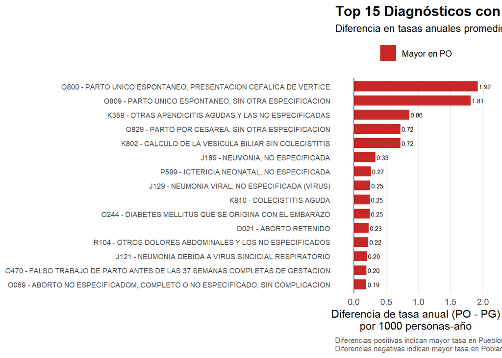

```r
# Usar función modular graficar_diferencias_tasas()
# Esta función automáticamente:
# - Genera gráfico divergente (barras horizontales)
# - Colores: rojo (PO > PG), azul (PG > PO)
# - Ordena por magnitud de diferencia
# - Agrega etiquetas con valores
# - Formatea ejes y leyendas

graf_diferencias <- graficar_diferencias_tasas(
  datos = comparacion_diag,
  top_n = 15,
  ordenar_por = "abs",
  titulo = "Top 15 Diagnósticos con mayor diferencia de tasas anuales",
  subtitulo = "Diferencia en tasas anuales promedio por 1000 persona-años (2010-2022)",
  color_po = "#C62828",
  color_pg = "#1565C0",
  mostrar_etiquetas = TRUE,
  tamano_etiquetas = 2.3
)

print(graf_diferencias)
```

```r
# Guardar
guardar_multiformato(graf_diferencias, "perfiles/diferencias_tasas_po_pg", 13, 9, 300)

cat("✓ Gráfico guardado en: resultados_tesis/perfiles/\n")
```

```
✓ Gráfico guardado en: resultados_tesis/perfiles/
```

## 6. Análisis de Sobrerrepresentación

### 6.1. Top diagnósticos sobrerrepresentados en PO

```r
cat("\n═══ DIAGNÓSTICOS SOBRERREPRESENTADOS EN PO ═══\n")
```

```
═══ DIAGNÓSTICOS SOBRERREPRESENTADOS EN PO ═══
```

```r
# Filtrar diagnósticos con RR ≥ 1.5
sobrerrepresentados <- comparacion_diag %>%
  filter(rr_crudo >= 1.5) %>%
  arrange(desc(rr_crudo)) %>%
  select(DIAG_COMPLETO, tasa_anual_po, tasa_anual_pg, rr_crudo, dif_tasa_anual)

cat("Total diagnósticos sobrerrepresentados (RR ≥ 1.5):", nrow(sobrerrepresentados), "\n\n")
```

```
Total diagnósticos sobrerrepresentados (RR ≥ 1.5): 11
```

```r
if(nrow(sobrerrepresentados) > 0) {
  cat("TOP 10 DIAGNÓSTICOS MÁS SOBRERREPRESENTADOS:\n")

  top10_sobre <- head(sobrerrepresentados, 10)

  for(i in 1:min(10, nrow(top10_sobre))) {
    cat(sprintf("\n%d. %s\n", i, top10_sobre$DIAG_COMPLETO[i]))
    cat(sprintf("   • Tasa PO: %.2f x1000 p-a\n", top10_sobre$tasa_anual_po[i]))
    cat(sprintf("   • Tasa PG: %.2f x1000 p-a\n", top10_sobre$tasa_anual_pg[i]))
    cat(sprintf("   • RR: %.2f (PO tiene %.0f%% más riesgo)\n",
                top10_sobre$rr_crudo[i],
                (top10_sobre$rr_crudo[i] - 1) * 100))
    cat(sprintf("   • Diferencia absoluta: %.2f x1000 p-a\n", top10_sobre$dif_tasa_anual[i]))
  }
}
```

```
TOP 10 DIAGNÓSTICOS MÁS SOBRERREPRESENTADOS:

1. J129 - NEUMONIA VIRAL, NO ESPECIFICADA (VIRUS)
   • Tasa PO: 0.51 x1000 p-a
   • Tasa PG: 0.25 x1000 p-a
   • RR: 1.99 (PO tiene 99% más riesgo)
   • Diferencia absoluta: 0.25 x1000 p-a

2. R104 - OTROS DOLORES ABDOMINALES Y LOS NO ESPECIFICADOS
   • Tasa PO: 0.45 x1000 p-a
   • Tasa PG: 0.23 x1000 p-a
   • RR: 1.97 (PO tiene 97% más riesgo)
   • Diferencia absoluta: 0.22 x1000 p-a

3. J121 - NEUMONIA DEBIDA A VIRUS SINCICIAL RESPIRATORIO
   • Tasa PO: 0.42 x1000 p-a
   • Tasa PG: 0.22 x1000 p-a
   • RR: 1.92 (PO tiene 92% más riesgo)
   • Diferencia absoluta: 0.20 x1000 p-a

4. O069 - ABORTO NO ESPECIFICADOM, COMPLETO O NO ESPECIFICADO, SIN COMPLICACION
   • Tasa PO: 0.41 x1000 p-a
   • Tasa PG: 0.22 x1000 p-a
   • RR: 1.89 (PO tiene 89% más riesgo)
   • Diferencia absoluta: 0.19 x1000 p-a

5. O800 - PARTO UNICO ESPONTANEO, PRESENTACION CEFALICA DE VERTICE
   • Tasa PO: 4.15 x1000 p-a
   • Tasa PG: 2.23 x1000 p-a
   • RR: 1.86 (PO tiene 86% más riesgo)
   • Diferencia absoluta: 1.92 x1000 p-a

6. O470 - FALSO TRABAJO DE PARTO ANTES DE LAS 37 SEMANAS COMPLETAS DE GESTACION
   • Tasa PO: 0.43 x1000 p-a
   • Tasa PG: 0.23 x1000 p-a
   • RR: 1.85 (PO tiene 85% más riesgo)
   • Diferencia absoluta: 0.20 x1000 p-a

7. O809 - PARTO UNICO ESPONTANEO, SIN OTRA ESPECIFICACION
   • Tasa PO: 3.95 x1000 p-a
   • Tasa PG: 2.14 x1000 p-a
   • RR: 1.84 (PO tiene 84% más riesgo)
   • Diferencia absoluta: 1.81 x1000 p-a

8. O244 - DIABETES MELLITUS QUE SE ORIGINA CON EL EMBARAZO
   • Tasa PO: 0.61 x1000 p-a
   • Tasa PG: 0.36 x1000 p-a
   • RR: 1.68 (PO tiene 68% más riesgo)
   • Diferencia absoluta: 0.25 x1000 p-a

9. K805 - CALCULO DE CONDUCTO BILIAR SIN COLANGITIS NI COLECISTITIS
   • Tasa PO: 0.49 x1000 p-a
   • Tasa PG: 0.32 x1000 p-a
   • RR: 1.56 (PO tiene 56% más riesgo)
   • Diferencia absoluta: 0.18 x1000 p-a

10. K358 - OTRAS APENDICITIS AGUDAS Y LAS NO ESPECIFICADAS
   • Tasa PO: 2.41 x1000 p-a
   • Tasa PG: 1.55 x1000 p-a
   • RR: 1.55 (PO tiene 55% más riesgo)
   • Diferencia absoluta: 0.86 x1000 p-a
```

```r
cat("\n")
```

### 6.2. Top diagnósticos subrepresentados en PO

```r
cat("═══ DIAGNÓSTICOS SUBREPRESENTADOS EN PO ═══\n")
```

```
═══ DIAGNÓSTICOS SUBREPRESENTADOS EN PO ═══
```

```r
# Filtrar diagnósticos con RR ≤ 0.67
subrepresentados <- comparacion_diag %>%
  filter(rr_crudo <= 0.67) %>%
  arrange(rr_crudo) %>%
  select(DIAG_COMPLETO, tasa_anual_po, tasa_anual_pg, rr_crudo, dif_tasa_anual)

cat("Total diagnósticos subrepresentados (RR ≤ 0.67):", nrow(subrepresentados), "\n\n")
```

```
Total diagnósticos subrepresentados (RR ≤ 0.67): 0
```

```r
if(nrow(subrepresentados) > 0) {
  cat("TOP 10 DIAGNÓSTICOS MÁS SUBREPRESENTADOS:\n")

  top10_sub <- head(subrepresentados, 10)

  for(i in 1:min(10, nrow(top10_sub))) {
    cat(sprintf("\n%d. %s\n", i, top10_sub$DIAG_COMPLETO[i]))
    cat(sprintf("   • Tasa PO: %.2f x1000 p-a\n", top10_sub$tasa_anual_po[i]))
    cat(sprintf("   • Tasa PG: %.2f x1000 p-a\n", top10_sub$tasa_anual_pg[i]))
    cat(sprintf("   • RR: %.2f (PO tiene %.0f%% menos riesgo)\n",
                top10_sub$rr_crudo[i],
                (1 - top10_sub$rr_crudo[i]) * 100))
    cat(sprintf("   • Diferencia absoluta: %.2f x1000 p-a\n", top10_sub$dif_tasa_anual[i]))
  }
}

cat("\n")
```

## 7. Funcionalidades Avanzadas del Paquete ciecl

**Paquete ciecl - Herramientas CIE-10 Chile**

Esta sección está **temporalmente deshabilitada** mientras el paquete `ciecl` completa su implementación.

Las funcionalidades documentadas en USO_PAQUETE_CIECL.md estarán disponibles próximamente: - Búsqueda difusa (fuzzy matching) - Validación automática de códigos - Expansión jerárquica - Índices de comorbilidad - Benchmark de rendimiento

**Estado actual**: El paquete está cargado pero algunas funciones están en desarrollo.

### 7.1. Búsqueda difusa de diagnósticos (Fuzzy Matching)

**Warning**

**Temporalmente deshabilitado** - En desarrollo

```r
cat("\n═══ BÚSQUEDA DIFUSA DE DIAGNÓSTICOS ═══\n\n")

# Ejemplo: Buscar diagnósticos con typos o variaciones
terminos_busqueda <- c(
  "neumonia",      # Sin tilde
  "diabetis",      # Typo común
  "hipertencion",  # Error ortográfico
  "EPOC"           # Acrónimo
)

cat("Buscando términos con errores ortográficos usando fuzzy matching...\n\n")

resultados_fuzzy <- map_dfr(terminos_busqueda, function(termino) {
  cat("• Buscando:", termino, "\n")

  resultado <- cie_search(
    termino = termino,
    tipo = "descripcion",
    metodo = "fuzzy",
    max_resultados = 3
  )

  if(nrow(resultado) > 0) {
    cat("  Encontrados:", nrow(resultado), "resultados similares\n")
    cat("  Mejor match:", resultado$descripcion_completa[1], "\n\n")
  } else {
    cat("  Sin resultados\n\n")
  }

  resultado %>%
    mutate(termino_buscado = termino) %>%
    slice(1:3)
})

cat("✓ Búsqueda fuzzy completada\n")
cat("  Algoritmo: Jaro-Winkler distance (óptimo para términos médicos)\n\n")
```

### 7.2. Validación automática de códigos CIE-10

**Warning**

**Temporalmente deshabilitado** - En desarrollo

```r
cat("═══ VALIDACIÓN DE CÓDIGOS CIE-10 ═══\n\n")

# Ejemplo: Validar lista de códigos (algunos válidos, otros no)
codigos_test <- c(
  "J44",      # Válido: EPOC
  "I10",      # Válido: Hipertensión esencial
  "E11",      # Válido: Diabetes mellitus tipo 2
  "Z999",     # Inválido: No existe
  "INVALIDO", # Inválido: Formato incorrecto
  "O80",      # Válido: Parto único espontáneo
  "A00.0"     # Válido: Cólera por Vibrio cholerae 01
)

cat("Validando", length(codigos_test), "códigos...\n\n")

validacion <- cie_validate_vector(
  codigos = codigos_test,
  version = "10",
  strict = FALSE
)

# Mostrar resultados
cat("RESULTADOS DE VALIDACIÓN:\n")
for(i in 1:nrow(validacion)) {
  icono <- if_else(validacion$valido[i], "✓", "✗")
  cat(sprintf("%s %s: %s\n", icono, validacion$codigo[i], validacion$mensaje[i]))
}

n_validos <- sum(validacion$valido)
n_invalidos <- sum(!validacion$valido)
pct_validos <- (n_validos / nrow(validacion)) * 100

cat("\nRESUMEN:\n")
cat("  • Códigos válidos:", n_validos, sprintf("(%.1f%%)\n", pct_validos))
cat("  • Códigos inválidos:", n_invalidos, sprintf("(%.1f%%)\n", 100 - pct_validos))
cat("\n")
```

### 7.3. Expansión jerárquica de códigos

**Warning**

**Temporalmente deshabilitado** - En desarrollo

```r
cat("═══ EXPANSIÓN JERÁRQUICA DE CÓDIGOS ═══\n\n")

# Ejemplo: Expandir códigos a sus subcategorías
cat("Expansión de códigos CIE-10 a nivel subcategoría:\n\n")

# Expandir J44 (EPOC) a todos sus subcódigos
cat("1. EPOC (J44) → Subcategorías:\n")
j44_expandido <- cie_expand(
  codigo_base = "J44",
  nivel = "subcategoria"
)

if(nrow(j44_expandido) > 0) {
  for(i in 1:min(5, nrow(j44_expandido))) {
    cat(sprintf("   • %s: %s\n",
                j44_expandido$codigo[i],
                j44_expandido$descripcion_completa[i]))
  }
  cat("   Total:", nrow(j44_expandido), "subcategorías\n\n")
}

# Expandir E11 (Diabetes tipo 2)
cat("2. Diabetes tipo 2 (E11) → Subcategorías:\n")
e11_expandido <- cie_expand(
  codigo_base = "E11",
  nivel = "subcategoria"
)

if(nrow(e11_expandido) > 0) {
  for(i in 1:min(5, nrow(e11_expandido))) {
    cat(sprintf("   • %s: %s\n",
                e11_expandido$codigo[i],
                e11_expandido$descripcion_completa[i]))
  }
  if(nrow(e11_expandido) > 5) {
    cat(sprintf("   ... y %d más\n", nrow(e11_expandido) - 5))
  }
  cat("   Total:", nrow(e11_expandido), "subcategorías\n\n")
}

cat("✓ Expansión completada\n")
cat("  Utilidad: Agrupar diagnósticos relacionados para análisis\n\n")
```

### 7.4. Cálculo de índices de comorbilidad

**Warning**

**Temporalmente deshabilitado** - En desarrollo

```r
cat("═══ ÍNDICES DE COMORBILIDAD (CHARLSON/ELIXHAUSER) ═══\n\n")

# Ejemplo: Calcular índice de Charlson para primeros 1000 pacientes
cat("Calculando índice de Charlson para muestra de datos...\n\n")

# Preparar datos: necesitamos id y código de diagnóstico
muestra_comorbid <- datos_diag_preparados %>%
  slice(1:5000) %>%  # Muestra
  select(id = Id, codigo = DIAG1) %>%
  filter(!is.na(codigo))

cat("Muestra:", format(nrow(muestra_comorbid), big.mark = ","), "registros\n")
cat("Pacientes únicos:", format(n_distinct(muestra_comorbid$id), big.mark = ","), "\n\n")

# Calcular índice de Charlson
tryCatch({
  charlson <- cie_comorbid(
    data = muestra_comorbid,
    id_col = "id",
    codigo_col = "codigo",
    indice = "charlson",
    version_cie = "10"
  )

  # Resumen de scores
  if(nrow(charlson) > 0) {
    cat("DISTRIBUCIÓN DE SCORES CHARLSON:\n")
    tabla_scores <- charlson %>%
      count(score_charlson) %>%
      arrange(desc(n)) %>%
      mutate(porcentaje = (n / sum(n)) * 100)

    for(i in 1:min(5, nrow(tabla_scores))) {
      cat(sprintf("  Score %d: %s pacientes (%.1f%%)\n",
                  tabla_scores$score_charlson[i],
                  format(tabla_scores$n[i], big.mark = ","),
                  tabla_scores$porcentaje[i]))
    }

    cat("\nESTADÍSTICAS:\n")
    cat("  • Score promedio:", sprintf("%.2f", mean(charlson$score_charlson, na.rm = TRUE)), "\n")
    cat("  • Mediana:", median(charlson$score_charlson, na.rm = TRUE), "\n")
    cat("  • Rango:", min(charlson$score_charlson, na.rm = TRUE), "-",
        max(charlson$score_charlson, na.rm = TRUE), "\n\n")
  }
}, error = function(e) {
  cat("⚠ Función cie_comorbid() aún no implementada en paquete\n")
  cat("  Mensaje:", e$message, "\n\n")
})

cat("Nota: El índice de Charlson predice mortalidad a 1 año\n")
cat("      basándose en la presencia de comorbilidades específicas\n\n")
```

## 8. Perfiles Diagnósticos de Patologías Específicas

**Análisis Focalizado por Patología**

Esta sección demuestra cómo crear perfiles epidemiológicos para patologías específicas usando: - **Funciones modulares personalizadas**: `crear_perfil_patologia()`, `comparar_patologias()`, `desglosar_por_subtipo()` - **Códigos CIE-10 base**: Con opción de expandir a subcategorías (cuando `ciecl::cie_expand()` esté disponible) - **Análisis comparativo**: Tasas, RR y clasificación PO vs PG

**Nota**: Las funciones están diseñadas para trabajar con o sin el paquete `ciecl` completamente implementado.

### 8.1. Perfil: Enfermedades Respiratorias Crónicas

```r
cat("\n═══ PERFIL: ENFERMEDADES RESPIRATORIAS CRÓNICAS ═══\n\n")
```

```
═══ PERFIL: ENFERMEDADES RESPIRATORIAS CRÓNICAS ═══
```

```r
# Crear perfil usando función modular
perfil_respiratorias <- crear_perfil_patologia(
  datos = datos_diag_preparados,
  codigos_base = c("J44", "J45", "J46", "J47"),
  nombre_patologia = "Enfermedades Respiratorias Crónicas",
  pob_po = pob_po,
  pob_pg = pob_pg,
  anos_estudio = anos_estudio,
  total_egresos_po = total_egresos_po,
  total_egresos_pg = total_egresos_pg,
  expandir = TRUE,
  top_n = 5,
  verbose = TRUE
)
```

```
Expandiendo códigos de Enfermedades Respiratorias Crónicas ...
```

```
  Códigos base: 4 → Expandidos: 4

═══ ENFERMEDADES RESPIRATORIAS CRÓNICAS ═══

EGRESOS:
  • PO: 0 (0.0% del total)
  • PG: 0 (0.0% del total)

TASAS ANUALES (x1000 persona-años):
  • PO: 0.00
  • PG: 0.00
  • RR: No calculable

TOP 5 DIAGNÓSTICOS:
1. NA
   PO: NA | PG: NA | RR: NA
```

### 8.2. Perfil: Diabetes Mellitus y Complicaciones

```r
cat("═══ PERFIL: DIABETES MELLITUS Y COMPLICACIONES ═══\n\n")
```

```
═══ PERFIL: DIABETES MELLITUS Y COMPLICACIONES ═══
```

```r
# Crear perfil general de diabetes
perfil_diabetes <- crear_perfil_patologia(
  datos = datos_diag_preparados,
  codigos_base = c("E10", "E11", "E12", "E13", "E14"),
  nombre_patologia = "Diabetes Mellitus",
  pob_po = pob_po,
  pob_pg = pob_pg,
  anos_estudio = anos_estudio,
  total_egresos_po = total_egresos_po,
  total_egresos_pg = total_egresos_pg,
  expandir = TRUE,
  top_n = 5,
  verbose = TRUE
)
```

```
Expandiendo códigos de Diabetes Mellitus ...
```

```
  Códigos base: 5 → Expandidos: 5

═══ DIABETES MELLITUS ═══

EGRESOS:
  • PO: 0 (0.0% del total)
  • PG: 0 (0.0% del total)

TASAS ANUALES (x1000 persona-años):
  • PO: 0.00
  • PG: 0.00
  • RR: No calculable

TOP 5 DIAGNÓSTICOS:
1. NA
   PO: NA | PG: NA | RR: NA
```

```r
# Desglose por tipo de diabetes usando función de clasificación
cat("DESGLOSE POR TIPO DE DIABETES:\n")
```

```
DESGLOSE POR TIPO DE DIABETES:
```

```r
desglose_diabetes <- desglosar_por_subtipo(
  datos = perfil_diabetes$datos,
  clasificacion_fn = function(datos) {
    case_when(
      str_detect(datos$DIAG1, "^E10") ~ "Tipo 1 (insulinodependiente)",
      str_detect(datos$DIAG1, "^E11") ~ "Tipo 2 (no insulinodependiente)",
      str_detect(datos$DIAG1, "^E12") ~ "Relacionada con desnutrición",
      str_detect(datos$DIAG1, "^E13") ~ "Otras especificadas",
      str_detect(datos$DIAG1, "^E14") ~ "No especificada",
      TRUE ~ "Otras"
    )
  },
  pob_po = pob_po,
  pob_pg = pob_pg,
  anos_estudio = anos_estudio,
  verbose = TRUE
)
```

```
═══ DESGLOSE POR SUBTIPO ═══

NA:
   • Egresos: PO NA (NA%) | PG NA (NA%)
   • Tasas: PO NA | PG NA x1000 p-a
   • RR: NA
```

### 8.3. Perfil: Patologías del Embarazo, Parto y Puerperio

```r
cat("═══ PERFIL: EMBARAZO, PARTO Y PUERPERIO ═══\n\n")
```

```
═══ PERFIL: EMBARAZO, PARTO Y PUERPERIO ═══
```

```r
# Capítulo O completo (O00-O99)
cat("Buscando códigos del Capítulo O (Embarazo, parto y puerperio)...\n")
```

```
Buscando códigos del Capítulo O (Embarazo, parto y puerperio)...
```

```r
# Filtrar códigos que empiezan con O
datos_embarazo <- datos_diag_preparados %>%
  filter(str_detect(DIAG1, "^O"))

cat("  • Total egresos encontrados:", format(nrow(datos_embarazo), big.mark = ","), "\n\n")
```

```
  • Total egresos encontrados: 3,798,976
```

```r
# Estadísticas generales
n_emb_po <- sum(datos_embarazo$PERTENENCIA2 == 1)
n_emb_pg <- sum(datos_embarazo$PERTENENCIA2 == 0)

cat("EGRESOS OBSTÉTRICOS:\n")
```

```
EGRESOS OBSTÉTRICOS:
```

```r
cat("  • PO:", format(n_emb_po, big.mark = ","), "egresos\n")
```

```
  • PO: 713,013 egresos
```

```r
cat("  • PG:", format(n_emb_pg, big.mark = ","), "egresos\n")
```

```
  • PG: 3,085,963 egresos
```

```r
cat("  • % del total PO:", sprintf("%.1f%%", (n_emb_po / total_egresos_po) * 100), "\n")
```

```
  • % del total PO: 22.9%
```

```r
cat("  • % del total PG:", sprintf("%.1f%%", (n_emb_pg / total_egresos_pg) * 100), "\n\n")
```

```
  • % del total PG: 17.3%
```

```r
# Top 10 diagnósticos obstétricos
cat("TOP 10 DIAGNÓSTICOS OBSTÉTRICOS MÁS FRECUENTES:\n")
```

```
TOP 10 DIAGNÓSTICOS OBSTÉTRICOS MÁS FRECUENTES:
```

```r
top_emb <- datos_embarazo %>%
  group_by(DIAG_COMPLETO, PERTENENCIA2) %>%
  summarise(n = n(), .groups = "drop") %>%
  group_by(DIAG_COMPLETO) %>%
  summarise(
    n_po = sum(n[PERTENENCIA2 == 1], na.rm = TRUE),
    n_pg = sum(n[PERTENENCIA2 == 0], na.rm = TRUE),
    total = n_po + n_pg,
    .groups = "drop"
  ) %>%
  mutate(
    pct_po = (n_po / sum(n_po)) * 100,
    pct_pg = (n_pg / sum(n_pg)) * 100
  ) %>%
  arrange(desc(total)) %>%
  slice(1:10)

for(i in 1:nrow(top_emb)) {
  cat(sprintf("\n%d. %s\n", i, top_emb$DIAG_COMPLETO[i]))
  cat(sprintf("   • PO: %s (%.1f%%) | PG: %s (%.1f%%)\n",
              format(top_emb$n_po[i], big.mark = ","),
              top_emb$pct_po[i],
              format(top_emb$n_pg[i], big.mark = ","),
              top_emb$pct_pg[i]))
}
```

```
1. O800 - PARTO UNICO ESPONTANEO, PRESENTACION CEFALICA DE VERTICE
   • PO: 118,009 (16.6%) | PG: 432,196 (14.0%)

2. O809 - PARTO UNICO ESPONTANEO, SIN OTRA ESPECIFICACION
   • PO: 112,272 (15.7%) | PG: 414,657 (13.4%)

3. O829 - PARTO POR CESAREA, SIN OTRA ESPECIFICACION
   • PO: 75,714 (10.6%) | PG: 375,752 (12.2%)

4. O820 - PARTO POR CESAREA ELECTIVA
   • PO: 49,860 (7.0%) | PG: 306,448 (9.9%)

5. O021 - ABORTO RETENIDO
   • PO: 21,506 (3.0%) | PG: 101,564 (3.3%)

6. O342 - ATENCIÓN MATERNA POR CICATRIZ UTERINA DEBIDA A CIRUGÍA PREVIA
   • PO: 19,632 (2.8%) | PG: 99,448 (3.2%)

7. O821 - PARTO POR CESAREA DE EMERGENCIA
   • PO: 13,812 (1.9%) | PG: 81,241 (2.6%)

8. O244 - DIABETES MELLITUS QUE SE ORIGINA CON EL EMBARAZO
   • PO: 17,325 (2.4%) | PG: 70,397 (2.3%)

9. O470 - FALSO TRABAJO DE PARTO ANTES DE LAS 37 SEMANAS COMPLETAS DE GESTACION
   • PO: 12,187 (1.7%) | PG: 44,805 (1.5%)

10. O069 - ABORTO NO ESPECIFICADOM, COMPLETO O NO ESPECIFICADO, SIN COMPLICACION
   • PO: 11,622 (1.6%) | PG: 41,873 (1.4%)
```

```r
cat("\n")
```

### 8.4. Uso de función genérica para crear perfiles

```r
cat("═══ FUNCIÓN GENÉRICA PARA PERFILES DE PATOLOGÍAS ═══\n\n")
```

```
═══ FUNCIÓN GENÉRICA PARA PERFILES DE PATOLOGÍAS ═══
```

```r
cat("✓ Función crear_perfil_patologia() cargada desde R/perfiles/funciones_patologias.R\n\n")
```

```
✓ Función crear_perfil_patologia() cargada desde R/perfiles/funciones_patologias.R
```

```r
# EJEMPLO DE USO: Enfermedades hipertensivas
cat("EJEMPLO: Usando función para Hipertensión (I10-I15)\n\n")
```

```
EJEMPLO: Usando función para Hipertensión (I10-I15)
```

```r
perfil_hipertension <- crear_perfil_patologia(
  datos = datos_diag_preparados,
  codigos_base = c("I10", "I11", "I12", "I13", "I14", "I15"),
  nombre_patologia = "Enfermedades Hipertensivas",
  pob_po = pob_po,
  pob_pg = pob_pg,
  anos_estudio = anos_estudio,
  total_egresos_po = total_egresos_po,
  total_egresos_pg = total_egresos_pg,
  expandir = TRUE,
  top_n = 5,
  verbose = TRUE
)
```

```
Expandiendo códigos de Enfermedades Hipertensivas ...
```

```
  Códigos base: 6 → Expandidos: 6

═══ ENFERMEDADES HIPERTENSIVAS ═══

EGRESOS:
  • PO: 0 (0.0% del total)
  • PG: 0 (0.0% del total)

TASAS ANUALES (x1000 persona-años):
  • PO: 0.00
  • PG: 0.00
  • RR: No calculable

TOP 5 DIAGNÓSTICOS:
1. NA
   PO: NA | PG: NA | RR: NA
```

### 8.5. Comparación entre múltiples patologías

```r
cat("═══ COMPARACIÓN ENTRE PATOLOGÍAS PRINCIPALES ═══\n\n")
```

```
═══ COMPARACIÓN ENTRE PATOLOGÍAS PRINCIPALES ═══
```

```r
# Definir patologías de interés
patologias <- list(
  "Respiratorias crónicas" = c("J44", "J45", "J46", "J47"),
  "Diabetes" = c("E10", "E11", "E12", "E13", "E14"),
  "Hipertensión" = c("I10", "I11", "I12", "I13", "I14", "I15"),
  "Enfermedad renal crónica" = c("N18"),
  "Cardiopatías isquémicas" = c("I20", "I21", "I22", "I23", "I24", "I25")
)

# Usar función comparar_patologias() del módulo
resultados_comparacion <- comparar_patologias(
  datos = datos_diag_preparados,
  lista_patologias = patologias,
  pob_po = pob_po,
  pob_pg = pob_pg,
  anos_estudio = anos_estudio,
  total_egresos_po = total_egresos_po,
  total_egresos_pg = total_egresos_pg,
  expandir = TRUE,
  verbose = TRUE
)
```

```
═══ COMPARACIÓN ENTRE PATOLOGÍAS ═══

Analizando 5 patologías...

Expandiendo códigos de Respiratorias crónicas ...
```

```
  Códigos base: 4 → Expandidos: 4

═══ RESPIRATORIAS CRÓNICAS ═══

EGRESOS:
  • PO: 0 (0.0% del total)
  • PG: 0 (0.0% del total)

TASAS ANUALES (x1000 persona-años):
  • PO: 0.00
  • PG: 0.00
  • RR: No calculable

Expandiendo códigos de Diabetes ...
```

```
  Códigos base: 5 → Expandidos: 5

═══ DIABETES ═══

EGRESOS:
  • PO: 0 (0.0% del total)
  • PG: 0 (0.0% del total)

TASAS ANUALES (x1000 persona-años):
  • PO: 0.00
  • PG: 0.00
  • RR: No calculable

Expandiendo códigos de Hipertensión ...
```

```
  Códigos base: 6 → Expandidos: 6

═══ HIPERTENSIÓN ═══

EGRESOS:
  • PO: 0 (0.0% del total)
  • PG: 0 (0.0% del total)

TASAS ANUALES (x1000 persona-años):
  • PO: 0.00
  • PG: 0.00
  • RR: No calculable

Expandiendo códigos de Enfermedad renal crónica ...
```

```
  Códigos base: 1 → Expandidos: 1

═══ ENFERMEDAD RENAL CRÓNICA ═══

EGRESOS:
  • PO: 0 (0.0% del total)
  • PG: 0 (0.0% del total)

TASAS ANUALES (x1000 persona-años):
  • PO: 0.00
  • PG: 0.00
  • RR: No calculable

Expandiendo códigos de Cardiopatías isquémicas ...
```

```
  Códigos base: 6 → Expandidos: 6

═══ CARDIOPATÍAS ISQUÉMICAS ═══

EGRESOS:
  • PO: 0 (0.0% del total)
  • PG: 0 (0.0% del total)

TASAS ANUALES (x1000 persona-años):
  • PO: 0.00
  • PG: 0.00
  • RR: No calculable


═══ RESUMEN COMPARATIVO ═══

1. Respiratorias crónicas
   • Tasas: PO 0.00 | PG 0.00 (x1000 p-a)
   • Diferencia: 0.00 x1000 p-a
   • RR: NA - Similar

2. Diabetes
   • Tasas: PO 0.00 | PG 0.00 (x1000 p-a)
   • Diferencia: 0.00 x1000 p-a
   • RR: NA - Similar

3. Hipertensión
   • Tasas: PO 0.00 | PG 0.00 (x1000 p-a)
   • Diferencia: 0.00 x1000 p-a
   • RR: NA - Similar

4. Enfermedad renal crónica
   • Tasas: PO 0.00 | PG 0.00 (x1000 p-a)
   • Diferencia: 0.00 x1000 p-a
   • RR: NA - Similar

5. Cardiopatías isquémicas
   • Tasas: PO 0.00 | PG 0.00 (x1000 p-a)
   • Diferencia: 0.00 x1000 p-a
   • RR: NA - Similar
```

```r
cat("\n✓ Análisis de patologías específicas completado\n\n")
```

```
✓ Análisis de patologías específicas completado
```